# Basics IV: Data Visualizations Using ggplot

### Step 4: customize our histogram

Let’s make our graph look better. We’ll make 3 changes:

- The bins (individual bars) are too wide (defaulted to 30 minutes) - we want a more fine-grained representation
- The color is bland
- The inside of the bars is the same color as the outside - I don’t like this, personally.

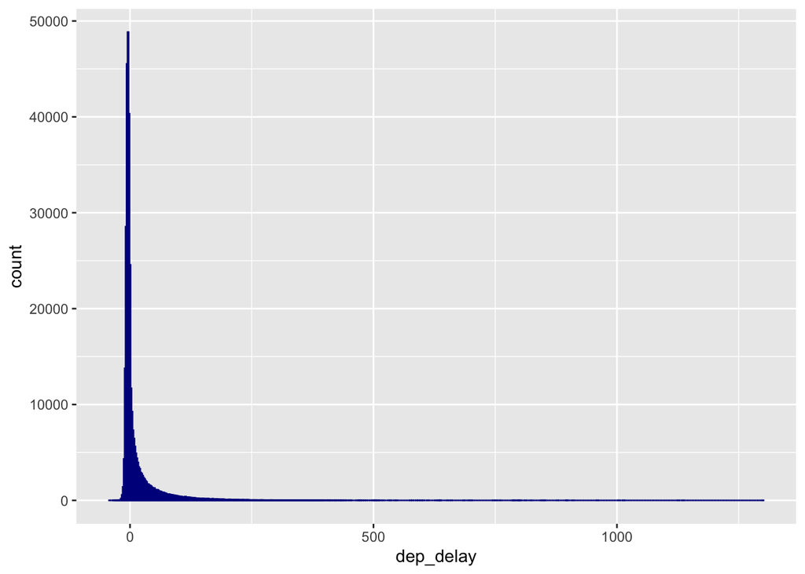

```r
ggplot(data = flights, aes(x = dep_delay)) +
  geom_histogram(binwidth = 2, color = "darkblue", fill = "lightblue")
```

We don’t need any more layers, so we’ll skip step 5: add further layers.

### Step 6: Finalize the plot

We need to further finalize the plot. There are 3 changes I want to make:

- I want to zoom in the X axis - we have some extreme outliers here (some flights are *really* late).
- Let’s add/customize our labels - those variable names are not adequate.
- I don’t love the gray background of the plot area.

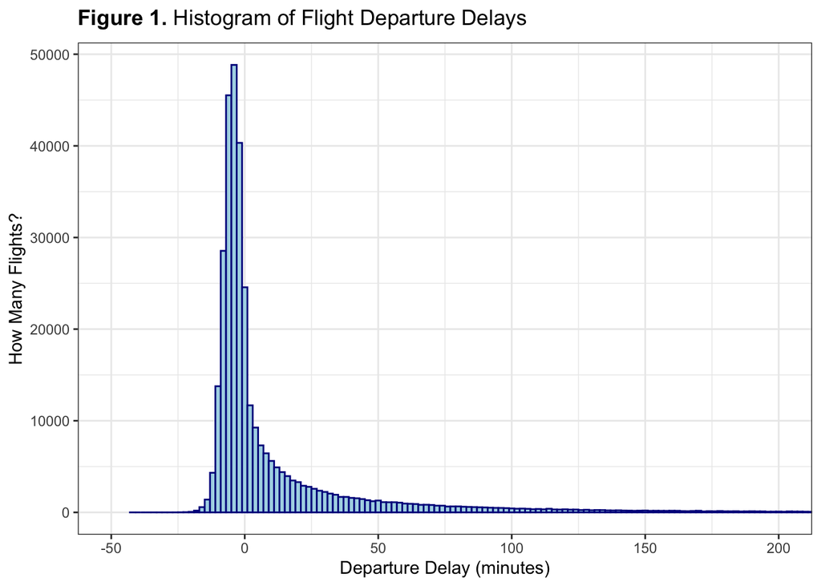

```r
ggplot(data = flights, aes(x = dep_delay)) +
  geom_histogram(binwidth = 2, color = "darkblue", fill = "lightblue") +
  coord_cartesian(xlim = c(-50, 200)) + # This zooms in the graph
  labs(
    x = "Departure Delay (minutes)",
    y = "How Many Flights?",
    title = expression(paste(bold("Figure 1."), " Histogram of Flight Departure Delays"))
  ) + theme_bw()
```

## Density Plot

Next, let’s make a density plot. We’ll start with our histogram, but change the *geom_histogram* to *geom_density*:

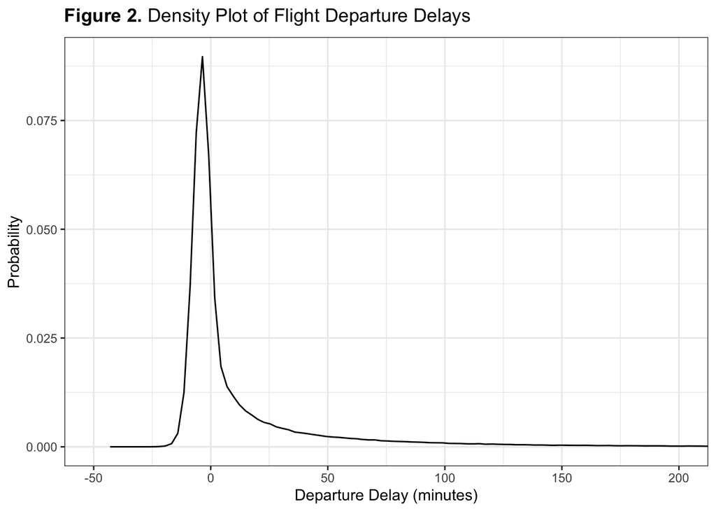

```r
ggplot(data = flights, aes(x = dep_delay)) +
  geom_density() +
  coord_cartesian(xlim = c(-50, 200)) + # This zooms in the graph
  labs(
    x = "Departure Delay (minutes)",
    y = "Probability",
    title = expression(paste(bold("Figure 2."), " Density Plot of Flight Departure Delays"))
  ) + theme_bw()
```

That’s OK, but we can do better. Let’s customize the density plot layer by:

- Changing the line color
- Changing the line type
- Adding a fill

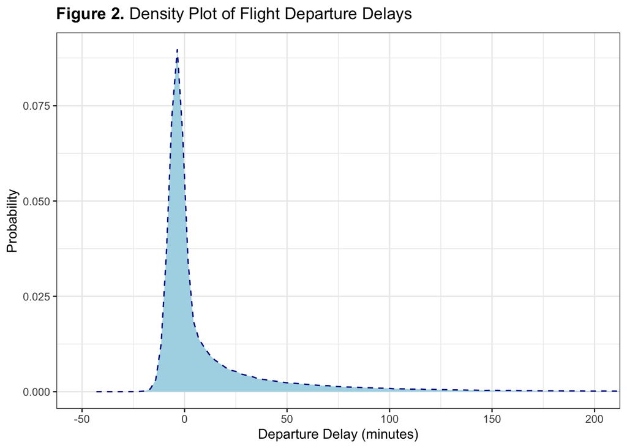

```r
ggplot(data = flights, aes(x = dep_delay)) +
  geom_density(color = "darkblue", linetype = 2, fill = "lightblue") +
  coord_cartesian(xlim = c(-50, 200)) + # This zooms in the graph
  labs(
    x = "Departure Delay (minutes)",
    y = "Probability",
    title = expression(paste(bold("Figure 2."), " Density Plot of Flight Departure Delays"))
  ) + theme_bw()
```

## Combining the Density Plot and Histogram

I love putting the density plots and histograms together. They’re highly compatible.

BUT, this takes a bit of work because the Y axes are different for these two plot types and we need to make them match.

Notice:

- In the geom_histogram, the Y axis is defined as aes(y = ..density..). In other words, we’re saying “use the density plot’s y axis scale instead.”
- Putting the histogram lower in the code puts the bars on top of the density plot.
- But, since I still want to see the density plot, I’ve made the bars somewhat transparent using alpha = 0.75. 0 is invisible, 1 is solid.

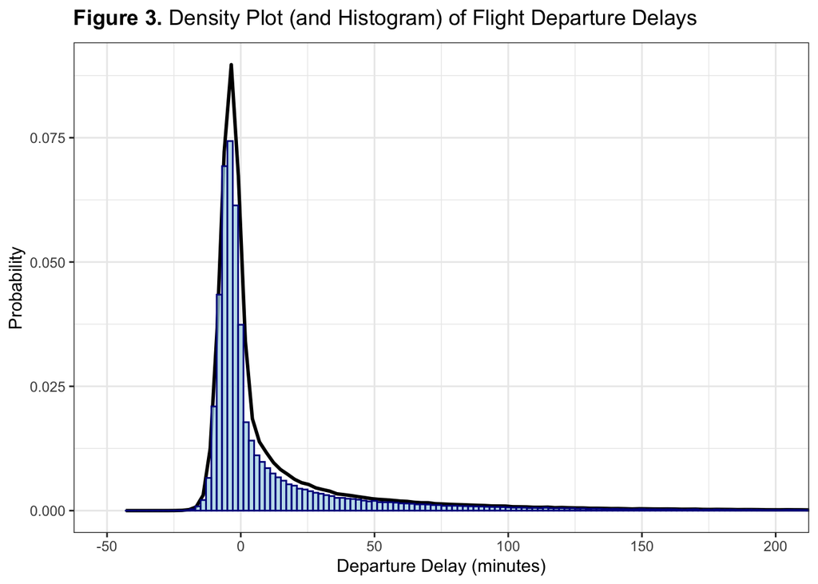

```r
ggplot(data = flights, aes(x = dep_delay)) +
  geom_density(color = "black", linetype = 1, size = 1) +
  geom_histogram(aes(y = ..density..), binwidth = 2, color = "darkblue", fill = "lightblue", alpha = 0.75) + # We have to put these two plots on the same scale
  coord_cartesian(xlim = c(-50, 200)) + # This zooms in the graph
  labs(
    x = "Departure Delay (minutes)",
    y = "Probability",
    title = expression(paste(bold("Figure 3."), " Density Plot (and Histogram) of Flight Departure Delays"))
  ) + theme_bw()
```

21. Using the *mtcars* data (which is preloaded in R, so just say *data = mtcars* in ggplot), make the graph below.
    - **Note:** The histogram bin width is .2. The histogram color is “black” and the fill is “gray40”. The density plot color is “black” and the fill is “alpha(”gray”, 0.5)“.
    - Also note the X axis label.

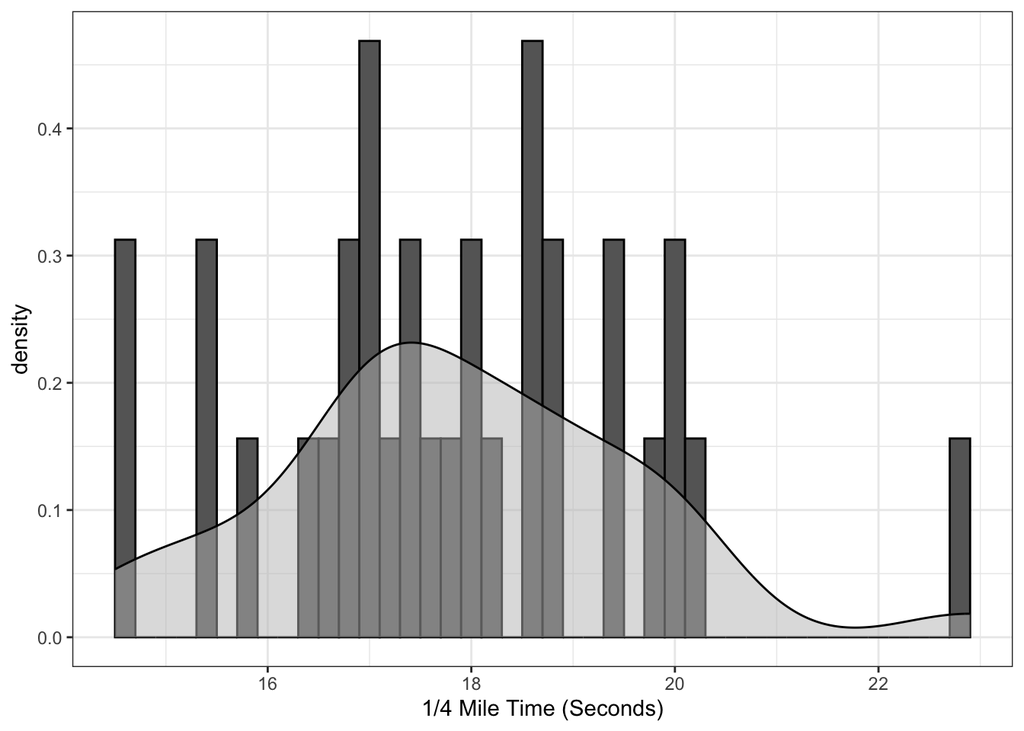

## Scatterplot

It’s scatterplot time!

In this graph, we’ll show the relationship between distance traveled and time in the air. This one takes longer to run, because there are many points to plot

Note: google “ggplot shapes” to find the number codes for different shapes. Or go here: (http://sape.inf.usi.ch/quick-reference/ggplot2/shape) Only shapes 21-25 can take a *fill* aesthetic that is different from their *color*.

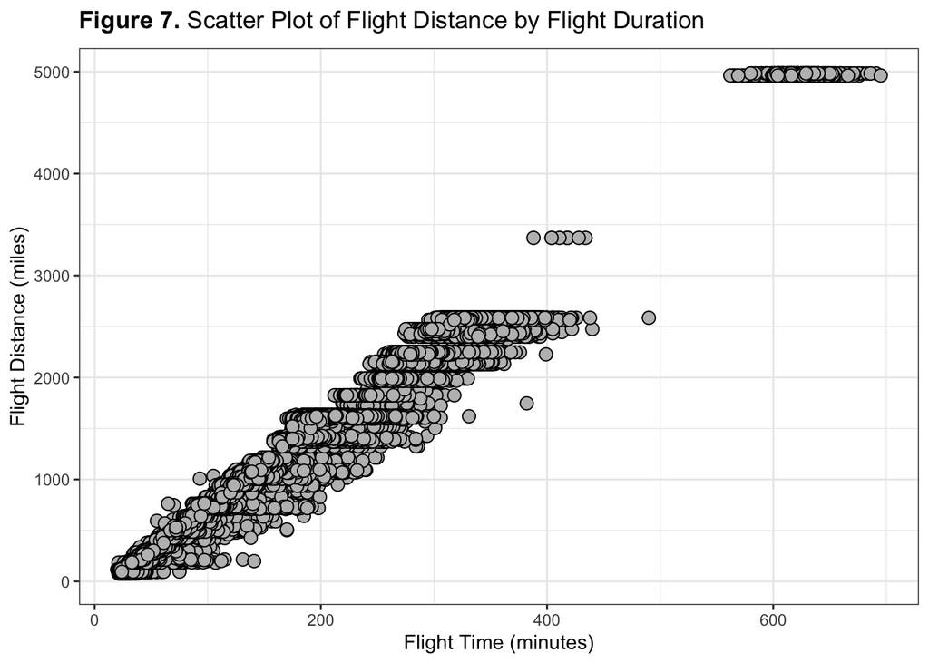

```r
ggplot(data = flights, aes(y = distance, x = air_time)) +
  geom_point(color = "black", fill = "gray", shape = 21, size = 3) +
  labs(
    y = "Flight Distance (miles)",
    x = "Flight Time (minutes)",
    title = expression(paste(bold("Figure 7. "), "Scatter Plot of Flight Distance by Flight Duration"))
  ) + theme_bw()
```

But now, let’s add a trend line using *geom_smooth*.

- *method = lm*. This says we want to make a regression line.
- *formula = y ~ x*. This shows the formula for our regression line. In this case, a straight line.

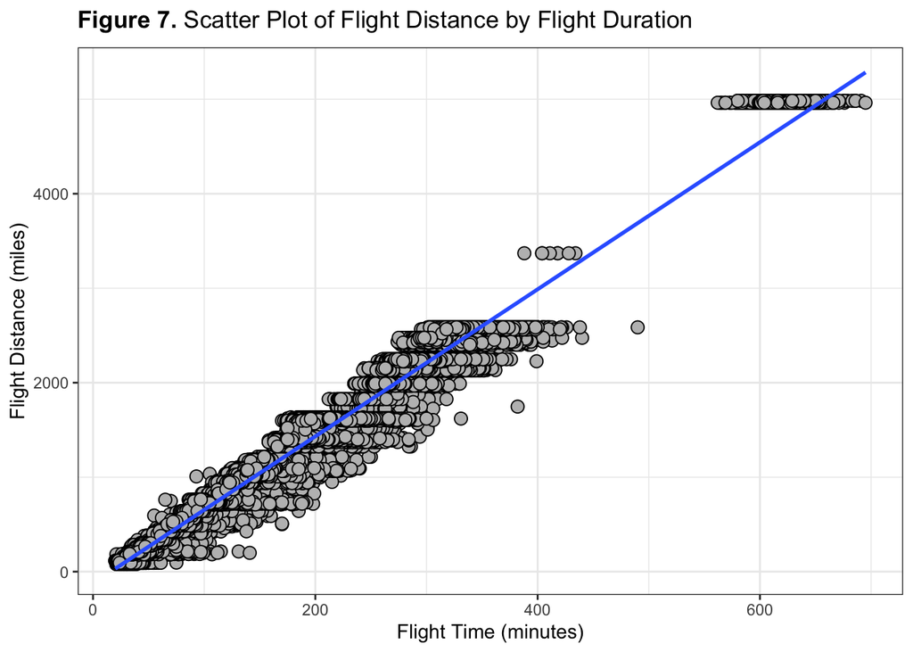

```r
ggplot(data = flights, aes(y = distance, x = air_time)) +
  geom_point(color = "black", fill = "gray", shape = 21, size = 3) +
  geom_smooth(method = lm, formula = y ~ x) +
  labs(
    y= "Flight Distance (miles)",
    x = "Flight Time (minutes)",
    title = expression(paste(bold("Figure 7. "), "Scatter Plot of Flight Distance by Flight Duration"))
  ) + theme_bw()
```

That’s a strong linear trend!

Let’s make the points and lines different for the different airports.

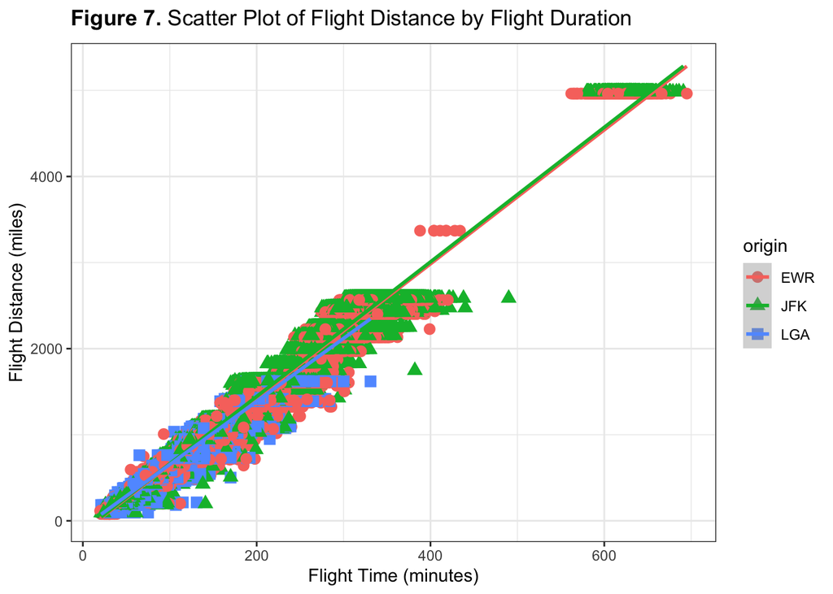

```r
ggplot(data = flights, aes(y = distance, x = air_time)) +
  geom_point(aes(color = origin, fill = origin, shape = origin), size = 3) +
  geom_smooth(method = lm, formula = y ~ x, aes(color = origin)) +
  labs(
    y= "Flight Distance (miles)",
    x = "Flight Time (minutes)",
    title = expression(paste(bold("Figure 7. "), "Scatter Plot of Flight Distance by Flight Duration"))
  ) + theme_bw()
```

### Picking Our Own Aesthetics

Wouldn’t it be nice to specify what the colors, shapes, etc. should be? We can do that!

We can use a pre-build color palette, like these: (http://www.cookbook-r.com/Graphs/Colors_(ggplot2)/#palettes-color-brewer)

Or we can define our own, using these colors: (http://sape.inf.usi.ch/quick-reference/ggplot2/colour)

Instead of typing the whole graph code over and over, we’ll give the graph a name and then add to it, like so:

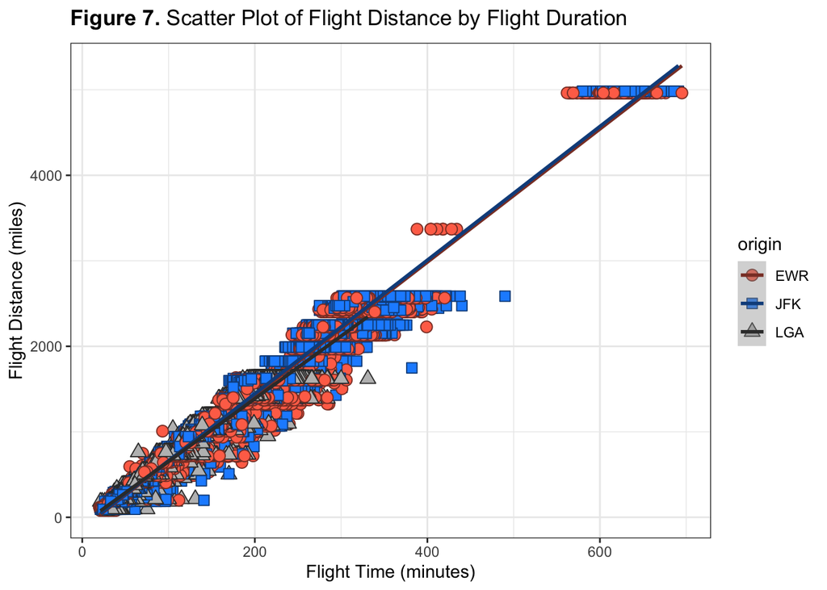

```r
flightscatter <- ggplot(data = flights, aes(y = distance, x = air_time)) +
  geom_point(aes(color = origin, fill = origin, shape = origin), size = 3) +
  geom_smooth(method = lm, formula = y ~ x, aes(color = origin)) +
  labs(
    y= "Flight Distance (miles)",
    x = "Flight Time (minutes)",
    title = expression(paste(bold("Figure 7. "), "Scatter Plot of Flight Distance by Flight Duration"))
  ) + theme_bw()

flightscatter +
    scale_color_manual(values = c("coral4", "dodgerblue4", "grey22")) +
    scale_fill_manual(values = c("coral1", "dodgerblue1", "grey")) +
    scale_shape_manual(values = c(21, 22, 24))
```

This allows you to mess around with colors without re-doing the whole graph each time.

Notice what I did there. I added to the graph scale_*aesthetic*_manual, then provided a vector with the specific values I wanted for that aesthetic.

### Adjusting the Legend

Let’s also rename and move the legend. How did I do those two things?

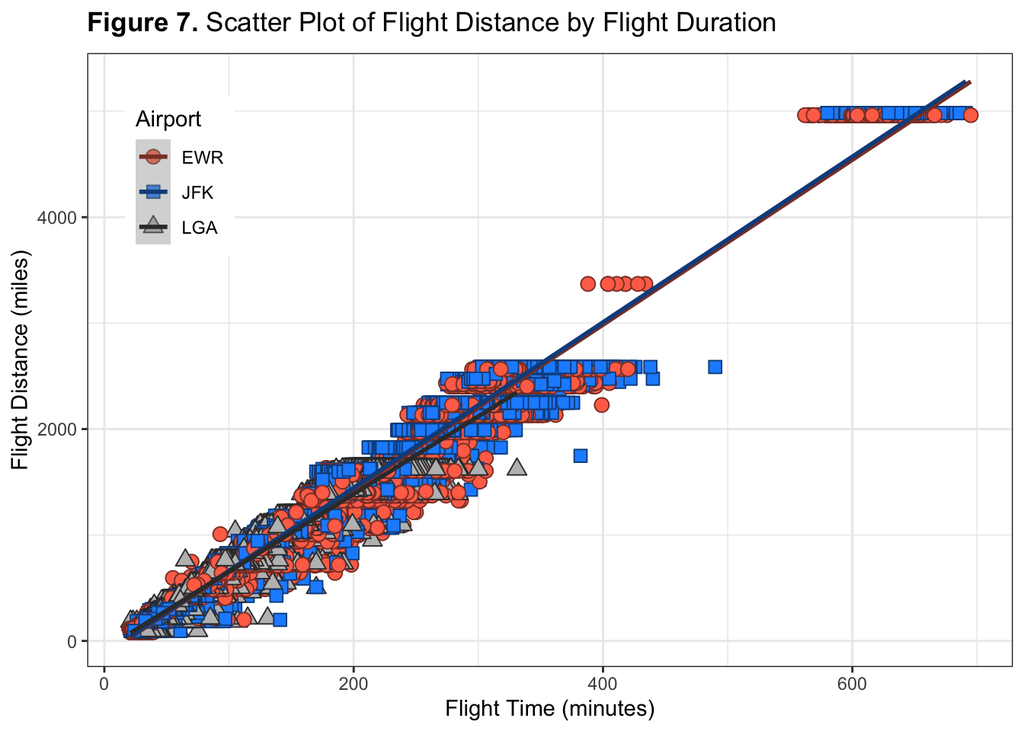

```r
flightscatter <- flightscatter +
    scale_color_manual(values = c("coral4", "dodgerblue4", "grey22")) +
    scale_fill_manual(values = c("coral1", "dodgerblue1", "grey")) +
    scale_shape_manual(values = c(21, 22, 24)) +
    labs(color = "Airport", fill = "Airport", shape = "Airport") +
    theme(
     legend.position = c(0.10, 0.80)
     # These numbers represent a proportion of the chart area,
     # first the x coord, then the y
    )

flightscatter
```

That looks pretty good. Now it’s your turn!

22. Using the *mtcars* data, make this graph:
    - **Note** The point size is 5, color = “black”, fill = “green4”, shape = 21. Use the same color/fill for the line.

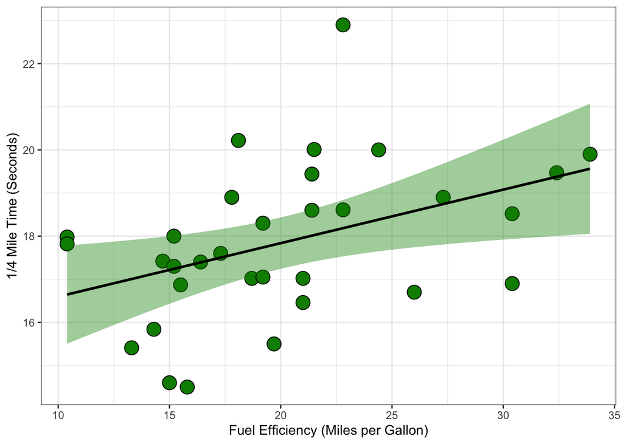

### Faceting

Let’s discuss faceting for a moment. To facet a graph is to create multiple separate plot areas. The code below divides the plot into three plots, one for each of the 3 airports. They are distributed horizontally. You could switch the *.* and the *origin* to arrange the facets vertically instead. And you could add another variable in place of the *.* to make a grid of graphs. See also *facet_wrap()*.

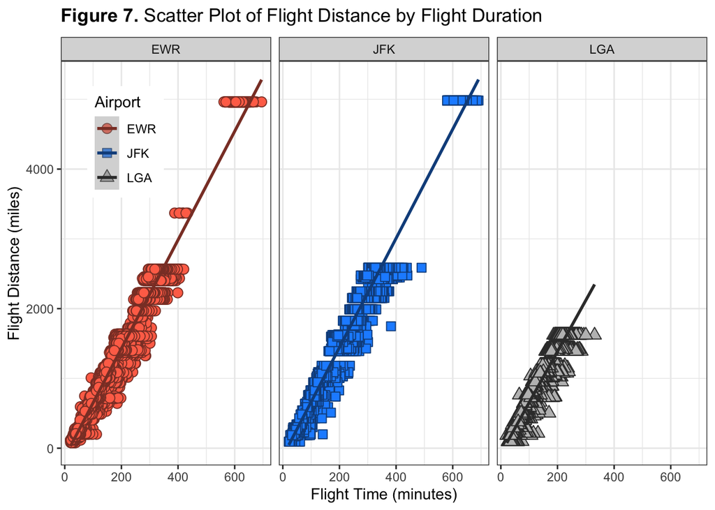

```r
flightscatter + facet_grid(. ~ origin)
```

## Bar Graph

Let’s make a bar graph. This takes a bit more setup than the others, because we usually want to plot the means, not the raw data. And if we want to add standard error bars (we do!), we’ll need to compute the standard errors as well.

```r
library(plotrix) # for the std.error function
flights_means <- flights %>%
  group_by(origin) %>%
  summarise(duration = mean(air_time, na.rm = TRUE), se = std.error(air_time))
```

Now to the actual plot. Note the *stat = “identity”*. By default, geom_bar plots the count of the data points (i.e. how many). So, without *stat = “identity”*, the bar chart would show us how many flights there were from each airport. But we don’t want that right now. Instead, we want to show the mean, which is the value in the data, the *identity* of the number in the cell. So we say so. Get it?

We also want the error bars to extend from the means (*duration*) up and down one standard error. Hence *aes(ymin=duration-se, ymax=duration+se)*.

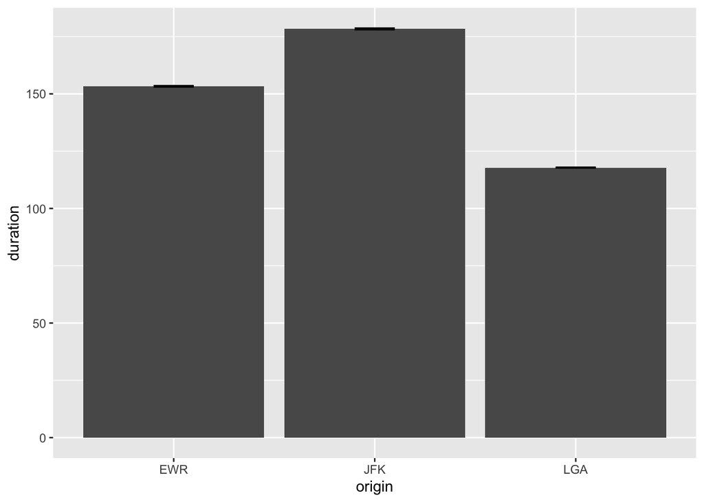

```r
ggplot(data = flights_means, aes(x = origin, y = duration)) +
  geom_bar(stat = "identity") +
  geom_errorbar(aes(ymin=duration-se, ymax=duration+se),
                width=.2, # Width of the error bars
                position=position_dodge(.9))
```

I’ll worrk about making this one pretty later.

23. Using the *mtcars* data, make this graph:
    - **Note** You’ll need to summarize the mtcars data to get the means and standard errors for each cylinder, then pass this *summarized* data tp ggplot. You’ll also need to use *as.factor()* to change cyl from a numeric variable to a factor.
    - **Note** Color = “black”, fill = default colors. The error bar width = 0.2
    - **Note** I took out the legend.

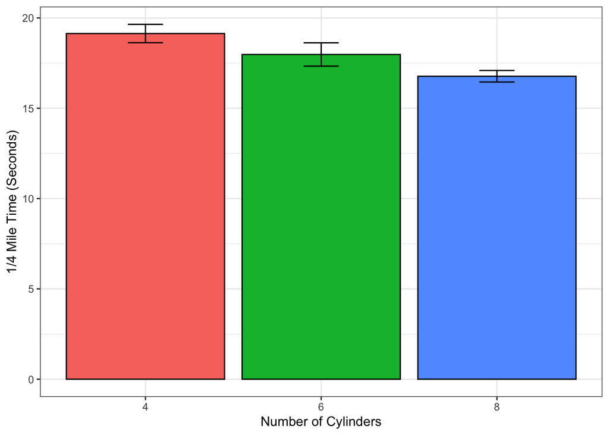

## Box Plot & Violin Plot

Let’s move on to box plots. The first difference is that we need to define both an X and Y axis. We’ll plot flight distance (Y axis) by origin (i.e. what airport the flight left from; X axis).

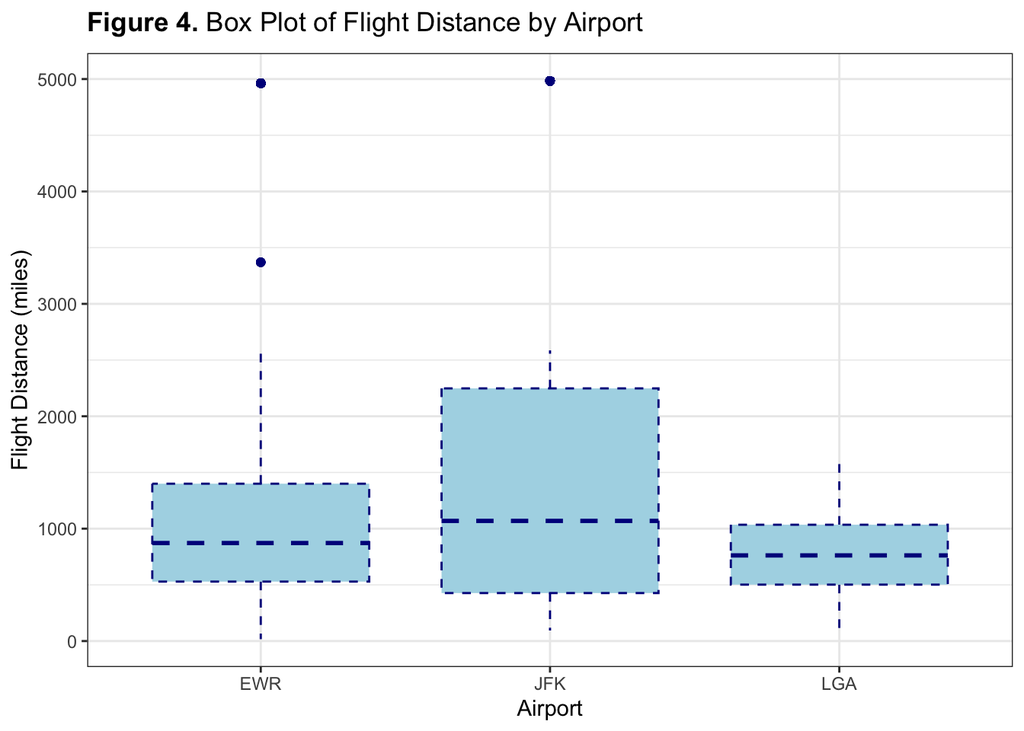

```r
ggplot(data = flights, aes(y = distance, x = origin)) +
  geom_boxplot(color = "darkblue", linetype = 2, fill = "lightblue") +
  labs(
    y = "Flight Distance (miles)",
    x = "Airport",
    title = expression(paste(bold("Figure 4. "), "Box Plot of Flight Distance by Airport"))
  ) + theme_bw()
```

*geom_violin* works just like *geom_boxplot*, so to make a violin plot we’ll just change the geom name:

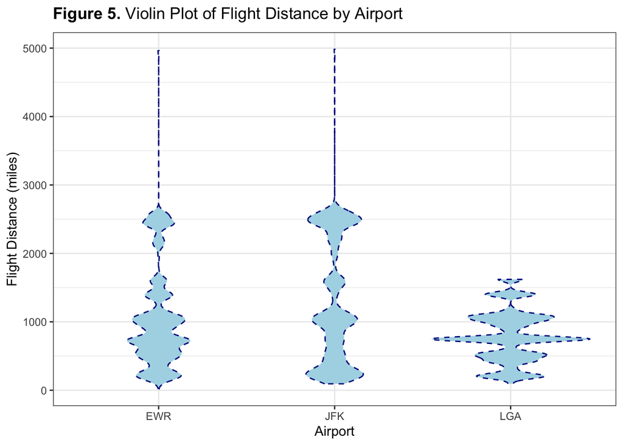

```r
ggplot(data = flights, aes(y = distance, x = origin)) +
  geom_violin(color = "darkblue", linetype = 2, fill = "lightblue") +
  labs(
    y = "Flight Distance (miles)",
    x = "Airport",
    title = expression(paste(bold("Figure 5. "), "Violin Plot of Flight Distance by Airport"))
  ) + theme_bw()
```

To combine violin and box plots, we have to adjust their widths.

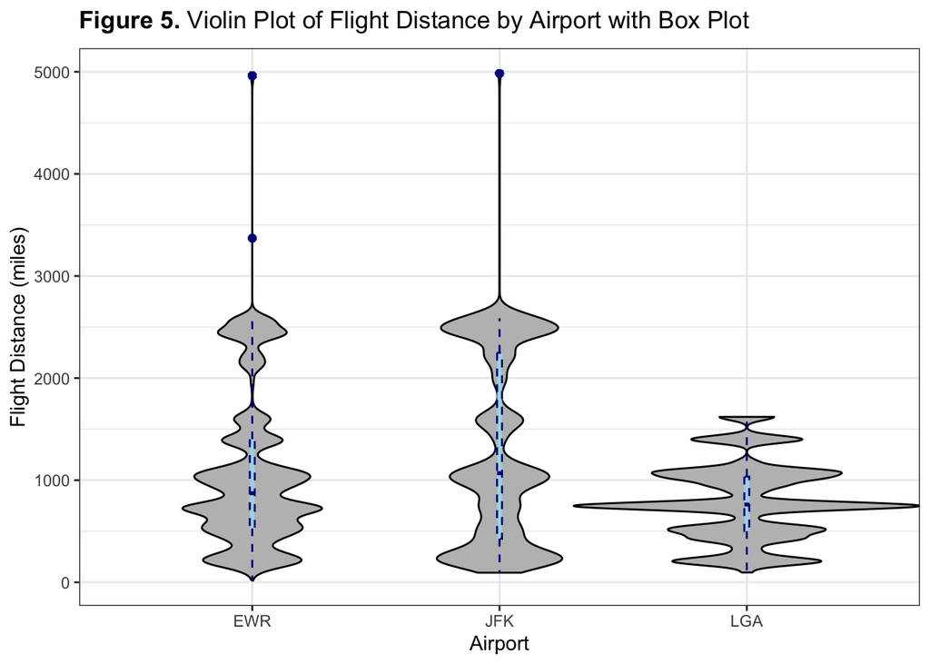

```r
ggplot(data = flights, aes(y = distance, x = origin)) +
  geom_violin(color = "black", linetype = 1, fill = "gray", width = 1.4) +
  geom_boxplot(color = "darkblue", linetype = 2, fill = "lightblue", width = 0.02) +
  labs(
    y = "Flight Distance (miles)",
    x = "Airport",
    title = expression(paste(bold("Figure 5. "), "Violin Plot of Flight Distance by Airport with Box Plot"))
  ) + theme_bw()
```

### Real Data: Do People Want to be Moral?

24. Read in your file ‘moraldatalong.csv’
25. Use this data to make the following graph:
    - **Note** Notice that the Traits are ordered from highest to lowest. You’ll have to figure out how to do this (hint: google “r reorder”). Also note that the fill colors for the traits are reordered, too, so you have to do the reordering 2 times in the code.

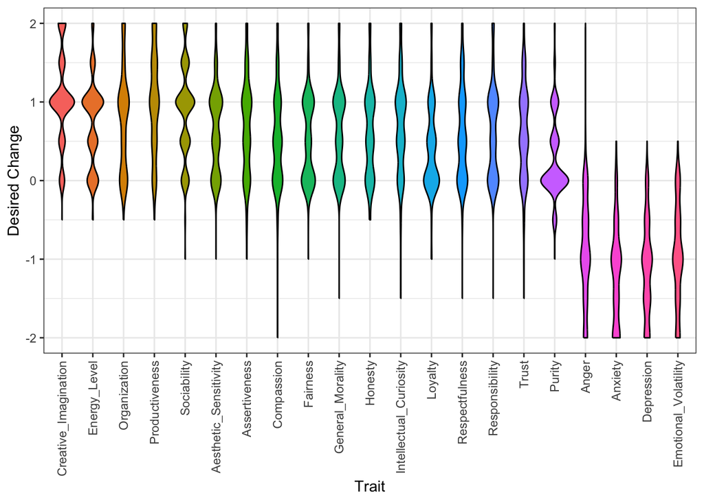

## Real Data: My Data Will Go On

Now let’s try some more advanced graph-making, including facets and themes.

26. Run this code to transform the pre-installed Titanic data into a long-form data set called TitanicData

```r
TitanicData <- data.frame(Titanic)
```

27. Now make the following graph:
    - **Note** Yes = gray15, No = red2, legend is at 0.6, 0.3. Also, use scales = “free_y” in the facet_grid.

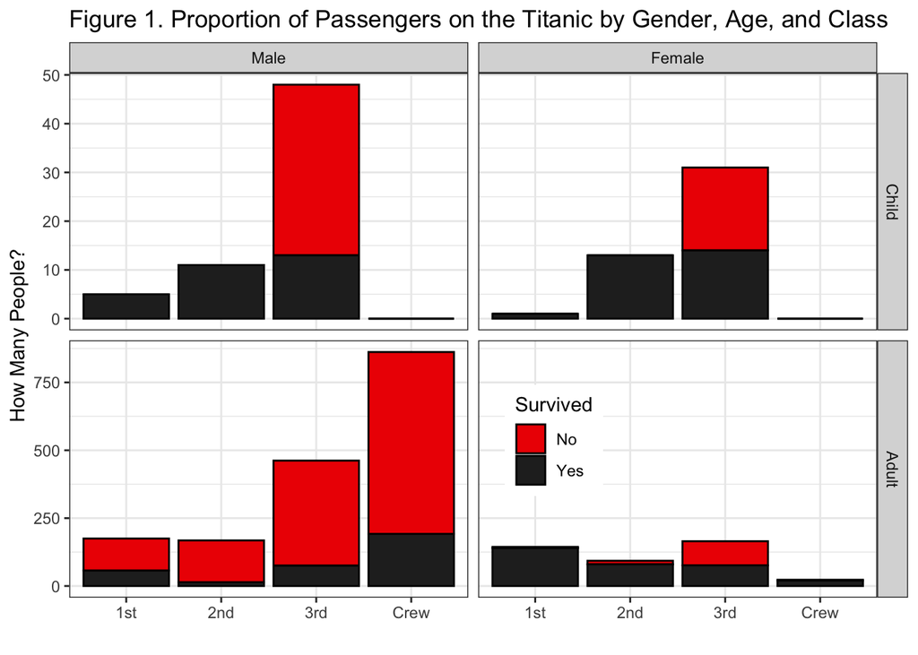

28. (Bonus) Alter your Titanic graph code from above to make the Figure Caption be APA style, like this:

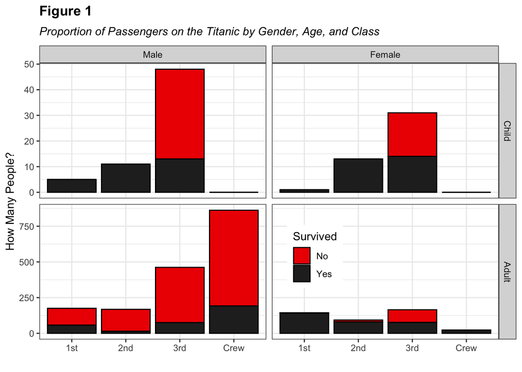

29. (Bonus) Alter your graph’s themes so it looks like this:
    - **Note** backgrounds are black, legend and strips are gray35, text is white and bold. panel grid lines (x axis) have been removed, as have minor y grid lines.

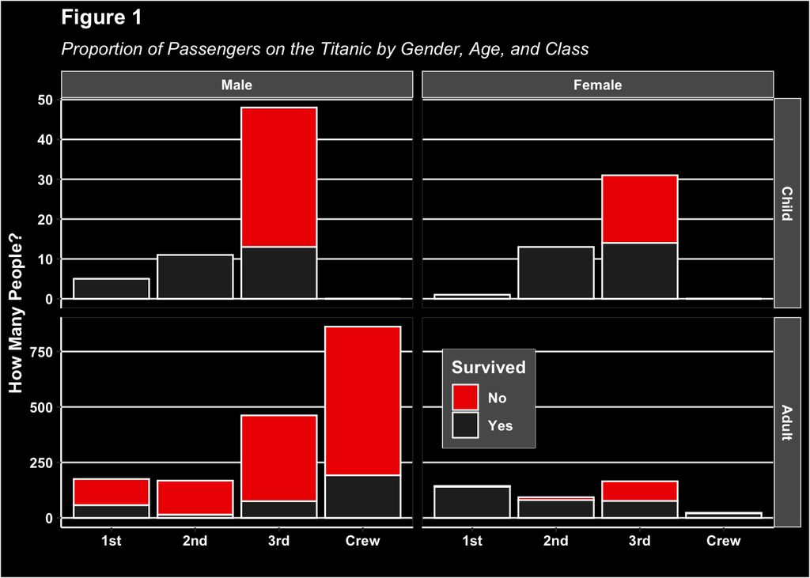

30. (Bonus) Now put this picture into your graph:

https://upload.wikimedia.org/wikipedia/commons/4/4f/Titanic_the_sinking.jpg

Like so: * **Hint** packages required include *jpeg* and *ggimage*

[figure not shown]

## Some other Graph Types

Here are some other graph types you may need to make someday.

### Line Graph

Let’s make a line graph. We’ll plot how departure delays change across the year.

We must do a bit of data preparation for this, since we want to plot the means, not the raw data.

```r
library(plotrix) # for the std.error function
month_means <- flights %>%
  group_by(month, origin) %>%
  summarise(departure_delay = mean(dep_delay, na.rm = TRUE), se = std.error(dep_delay, na.rm = TRUE))
```

And now on to the plot. We’ll put some points in (with *geom_point()*), and connect those points with *geom_line()*.

Other things I did (can you figure out which command does these things?):

- Added error bars (easy!)
- Formatted the x axis to show the month names instead of numbers
- Turned the month names sideways and moved them around a bit

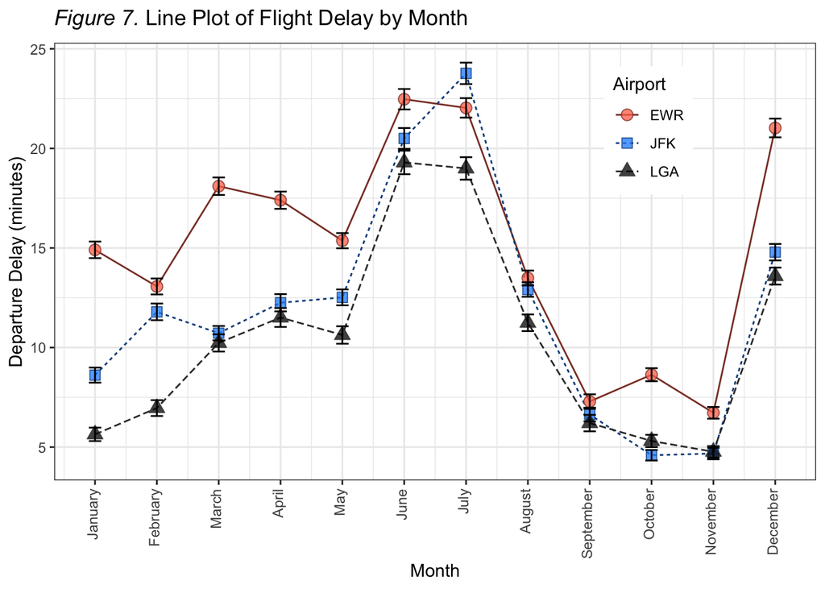

```r
ggplot(data = month_means, aes(y = departure_delay, x = month)) +
  geom_line(aes(color = origin, linetype = origin)) +
  geom_point(aes(color = origin, fill = origin, shape = origin), size = 3, alpha = 0.75) +
  geom_errorbar(aes(ymin=departure_delay-se, ymax=departure_delay+se),
                width=.2, # Width of the error bars
                position=position_dodge(.9)) +
  labs(
    y = "Departure Delay (minutes)",
    x = "Month",
    color = "Airport",
    linetype = "Airport",
    fill = "Airport",
    shape = "Airport",
    title = expression(paste(italic("Figure 7. "), "Line Plot of Flight Delay by Month"))
  ) + theme_bw() +
  scale_color_manual(values = c("coral4", "dodgerblue4", "grey22")) +
  scale_fill_manual(values = c("coral1", "dodgerblue1", "grey0")) +
  scale_shape_manual(values = c(21, 22, 24)) +
  scale_x_continuous(labels = c("January", "February", "March", "April", "May", "June", "July", "August", "September", "October", "November", "December"),
                     breaks = c(1, 2, 3, 4, 5, 6, 7, 8, 9, 10, 11, 12)
  ) + theme(axis.text.x = element_text(vjust = 0.25, hjust = 1, angle = 90),
            legend.position = c(0.78, 0.8))
```

### Bubble Plot

A bubble plot is really just a scatterplot, except that the size of the points varies by some 3rd variable.

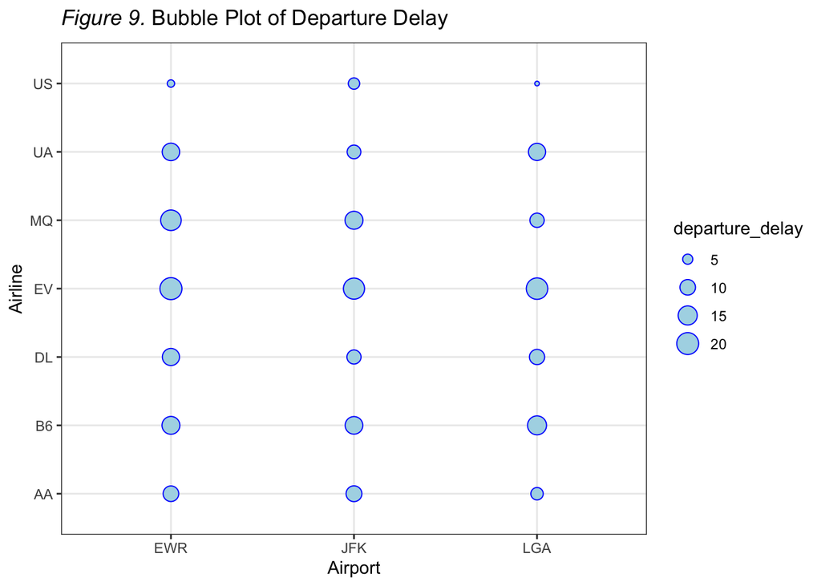

```r
library(plotrix) # for the std.error function
flights_means <- filter(flights, carrier %in% c("AA", "B6", "DL", "EV", "MQ", "UA", "US")) %>%
  group_by(origin, carrier) %>%
  summarise(duration = mean(air_time, na.rm = TRUE), departure_delay = mean(dep_delay, na.rm = TRUE), se = std.error(air_time, na.rm = TRUE))

ggplot(data = flights_means, aes(y =carrier, x = origin)) +
  geom_point(aes(size = departure_delay), color = "blue", shape = 21, fill = "lightblue") +
  labs(
    y= "Airline",
    x = "Airport",
    fill = "Departure Delay",
    title = expression(paste(italic("Figure 9. "), "Bubble Plot of Departure Delay"))
  ) + theme_bw()
```

### Heatmaps

To get a grid-like heatmap, use *geom_tile()* or *geom_raster()*

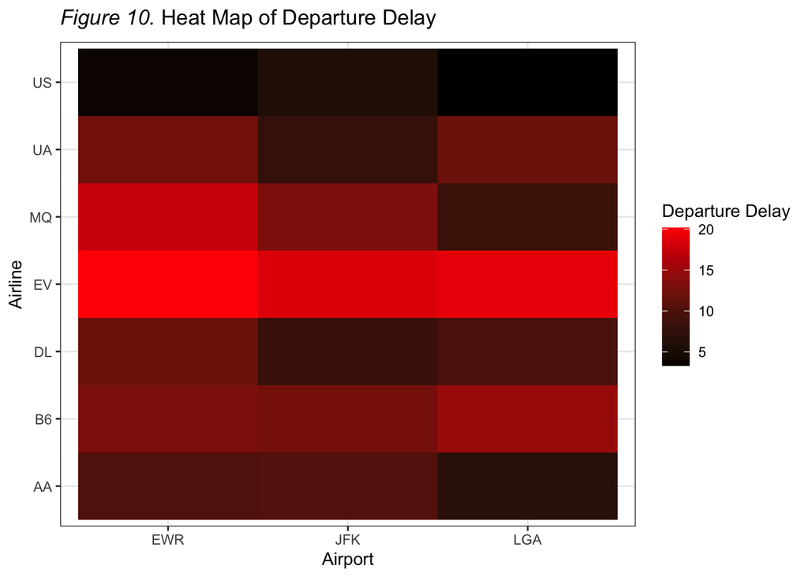

```r
ggplot(data = flights_means, aes(y =carrier, x = origin)) +
  geom_raster(aes(fill = departure_delay)) +
  scale_fill_gradient(low="black", high="red") +
  labs(
    y= "Airline",
    x = "Airport",
    fill = "Departure Delay",
    title = expression(paste(italic("Figure 10. "), "Heat Map of Departure Delay"))
  ) + theme_bw()
```

Now you’re ready to make some graphs of your own!

31. (Bonus) Read in ‘marriagedata.csv’ from Checklist 4. Make a line graph showing change in marital satisfaction over time. Include separate lines for husband and wife, and points with error bars in addition to the lines.

Go To Home Page